# Exercise Manner Prediction Using Measurement Body Devices

Javier Monterrubio

23/05/2015

The idea of this project is to be able to predict how well a person is doing some kind of exercices measuring his movements. For this we begin with a huge dataset of 6 user measures who performed barbell lifts correctly and incorrectly in 5 different ways.

First of all lets import and clean the dataset, removing possible predictors with NA values and some uneeded ones like timestamps, usernames, etc.

```r
readsubdataset <- function(datasettype = "training", directory = "./") {
      dataset <- read.table(paste(directory,"pml-",datasettype,".csv",sep = ""),
                            header = T,sep = ",",
                            na.strings=c("NA", "", " "))
      data.frame(dataset)
}

cleandataset <- function(df) {
  clean <- df[, colSums(is.na(df)) ==  0]
  drops <- c("cvtd_timestamp",
             "raw_timestamp_part_1",
             "raw_timestamp_part_2",
             "X",
             "new_window",
             "num_window",
             "user_name")
  clean[,!(names(clean) %in% drops)]
}

set.seed(666)
training <- readsubdataset()
clean <- cleandataset(training)
```

The first approach is to use a supervised classification algorithm like ‘rpart’ and use k-fold cross validation.

```r
inTrain <- createDataPartition(y=clean$classe, p=0.7, list=FALSE)
training1 <- clean[inTrain,]
testing1 <- clean[-inTrain,]
train_control1 <- trainControl(method="cv", number=10)
mod1 <- train(classe ~ ., data=training1, trControl = train_control1, method="rpart")
predictions1 <- predict(mod1,newdata=testing1)
confusionMatrix(predictions1, testing1$classe)$overall[1]
```

```
##  Accuracy
## 0.5012744
```

We can see the poor accuracy of this method (~50%) so lets try a new one, random forest in this case.

```r
mod2 <- randomForest(classe ~ ., importance=TRUE, data=training1)
mod2
```

```
##
## Call:
##  randomForest(formula = classe ~ ., data = training1, importance = TRUE)
##                Type of random forest: classification
##                      Number of trees: 500
## No. of variables tried at each split: 7
##
##         OOB estimate of  error rate: 0.52%
## Confusion matrix:
##      A    B    C    D    E class.error
## A 3900    4    1    0    1 0.001536098
## B   12 2640    6    0    0 0.006772009
## C    0   14 2380    2    0 0.006677796
## D    0    0   22 2228    2 0.010657194
## E    0    0    1    6 2518 0.002772277
```

The OOB (Out Of Bag error rate) is very low so i seems that the prediction accuracy will be very high. Lets see it:

```r
predictions2 <- predict(mod2,newdata=testing1)
confusionMatrix(predictions2, testing1$classe)
```

```
## Confusion Matrix and Statistics
##
##           Reference
## Prediction    A    B    C    D    E
##          A 1673    8    0    0    0
##          B    1 1129    3    0    0
##          C    0    2 1023   10    1
##          D    0    0    0  953    7
##          E    0    0    0    1 1074
##
## Overall Statistics
##
##                Accuracy : 0.9944
##                  95% CI : (0.9921, 0.9961)
##     No Information Rate : 0.2845
##     P-Value [Acc > NIR] : < 2.2e-16
##
##                   Kappa : 0.9929
##  Mcnemar's Test P-Value : NA
##
## Statistics by Class:
##
##                      Class: A Class: B Class: C Class: D Class: E
## Sensitivity            0.9994   0.9912   0.9971   0.9886   0.9926
## Specificity            0.9981   0.9992   0.9973   0.9986   0.9998
## Pos Pred Value         0.9952   0.9965   0.9875   0.9927   0.9991
## Neg Pred Value         0.9998   0.9979   0.9994   0.9978   0.9983
## Prevalence             0.2845   0.1935   0.1743   0.1638   0.1839
## Detection Rate         0.2843   0.1918   0.1738   0.1619   0.1825
## Detection Prevalence   0.2856   0.1925   0.1760   0.1631   0.1827
## Balanced Accuracy      0.9988   0.9952   0.9972   0.9936   0.9962
```

Good accuracy isn’t it? Here we can have an overfitting problem if we don’t do any cross validation. But before that, we are goint to make a pair of researchs. First one is to see the the variable importance.

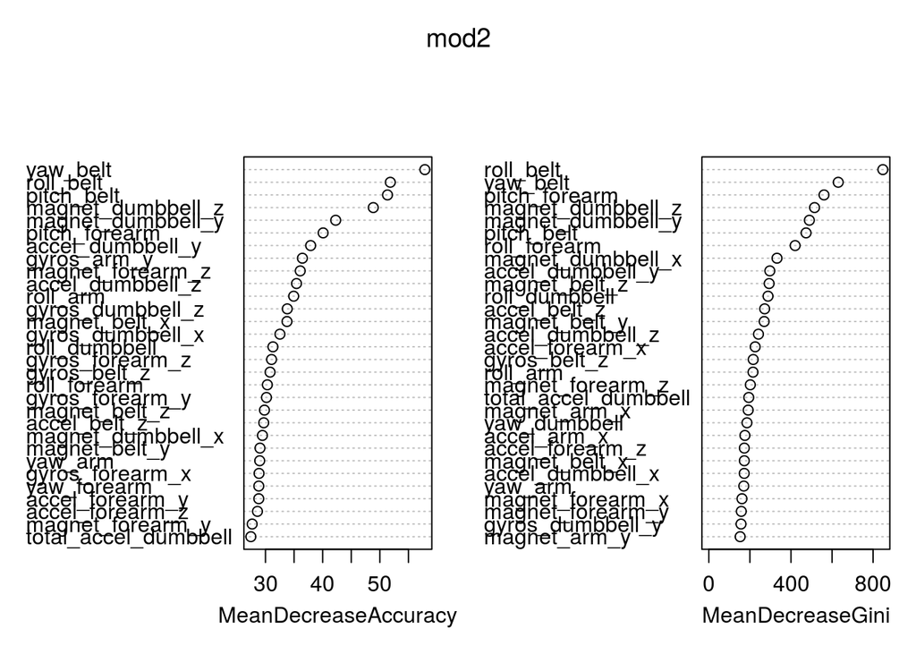

```r
varImpPlot(mod2)
```

Just for fun we are going to see some patterns in the predictors:

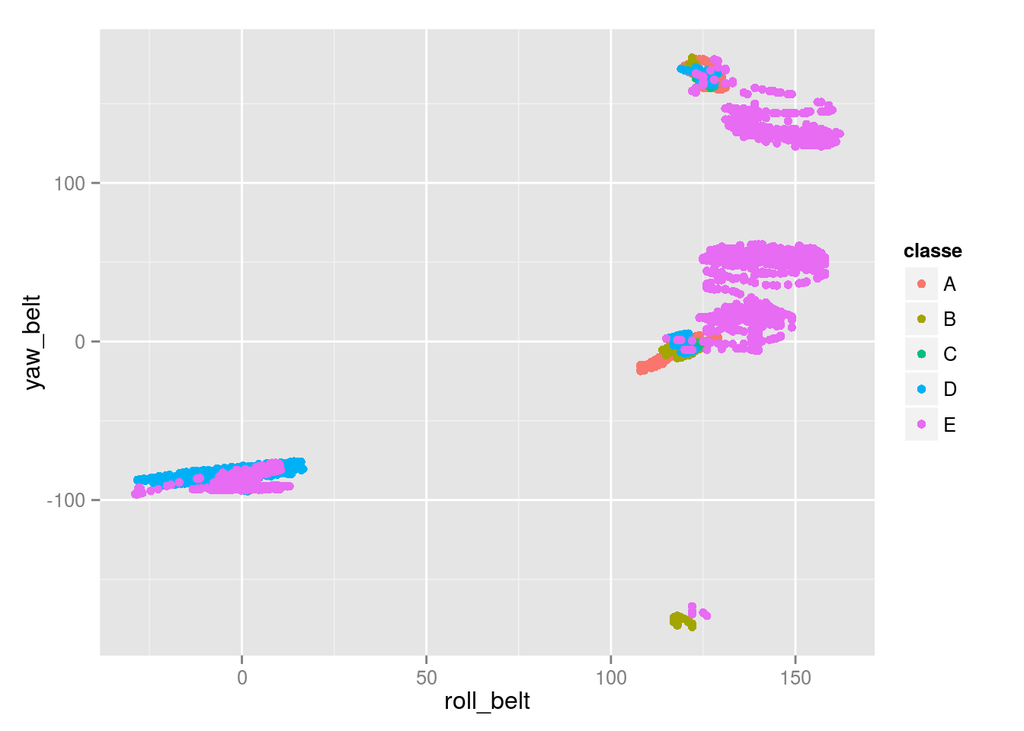

```r
qplot(roll_belt,yaw_belt,color=classe,data=training1)
```

Again,what happen if we remove some predictors of the model?

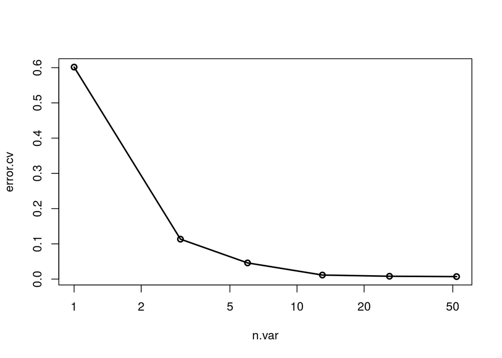

```r
result <- rfcv(training1[,-53],training1$classe)
with(result, plot(n.var, error.cv, log="x", type="o", lwd=2))
```

We can see that just with the first 15 the error is near 0.0. So selecting the 15 most important prefictors:

```r
mod3 <- randomForest(classe ~ roll_belt + yaw_belt + pitch_forearm + magnet_dumbbell_z +
                     magnet_dumbbell_y + pitch_belt + roll_forearm + magnet_dumbbell_x +
                     accel_dumbbell_y + magnet_belt_z + roll_dumbbell + accel_belt_z +
                     magnet_belt_y + accel_forearm_x + accel_dumbbell_y, importance=TRUE,
                     data=training1)
predictions3 <- predict(mod3,newdata=testing1)
confusionMatrix(predictions3, testing1$classe)$overall[1]
```

```
## Accuracy
## 0.986746
```

```r
train_control2 <- trainControl(method="cv", number=5)
mod4 <- train(classe ~ roll_belt + yaw_belt + pitch_forearm + magnet_dumbbell_z +
                     magnet_dumbbell_y + pitch_belt + roll_forearm + magnet_dumbbell_x +
                     accel_dumbbell_y + magnet_belt_z + roll_dumbbell + accel_belt_z +
                     magnet_belt_y + accel_forearm_x + accel_dumbbell_y,
              trControl = train_control2, method="rf", data=training1)
predictions4 <- predict(mod4,newdata=testing1)
confusionMatrix(predictions4, testing1$classe)
```

```
## Confusion Matrix and Statistics
##
##           Reference
## Prediction    A    B    C    D    E
##          A 1665   12    0    0    0
##          B    7 1102    9    1    3
##          C    1   21 1013   12    2
##          D    1    3    4  950    9
##          E    0    1    0    1 1068
##
## Overall Statistics
##
##                Accuracy : 0.9852
##                  95% CI : (0.9818, 0.9881)
##     No Information Rate : 0.2845
##     P-Value [Acc > NIR] : < 2.2e-16
##
##                   Kappa : 0.9813
##  Mcnemar's Test P-Value : NA
##
## Statistics by Class:
##
##                      Class: A Class: B Class: C Class: D Class: E
## Sensitivity            0.9946   0.9675   0.9873   0.9855   0.9871
## Specificity            0.9972   0.9958   0.9926   0.9965   0.9996
## Pos Pred Value         0.9928   0.9822   0.9657   0.9824   0.9981
## Neg Pred Value         0.9979   0.9922   0.9973   0.9972   0.9971
## Prevalence             0.2845   0.1935   0.1743   0.1638   0.1839
## Detection Rate         0.2829   0.1873   0.1721   0.1614   0.1815
## Detection Prevalence   0.2850   0.1907   0.1782   0.1643   0.1818
## Balanced Accuracy      0.9959   0.9817   0.9900   0.9910   0.9933
```

```r
mod4
```

[output not shown]

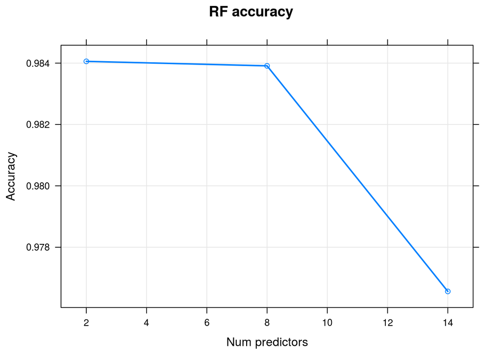

```r
plot(mod4, log = "y", lwd = 2, main = "RF accuracy", xlab = "Num predictors",
     ylab = "Accuracy")
```

Applying the model to predict the testing file:

```r
testing <- readsubdataset("testing")
cleanTesting <- cleandataset(testing)
predict(mod3,newdata=cleanTesting)
```

```
##  1  2  3  4  5  6  7  8  9 10 11 12 13 14 15 16 17 18 19 20
##  B  A  B  A  A  E  D  B  A  A  B  C  B  A  E  E  A  B  B  B
## Levels: A B C D E
```

To estimate the out of sample error:

```r
error <- as.numeric(1 - confusionMatrix(predictions4, testing1$classe)$overall[1]) * 100
paste0("Out of sample error estimation: ", round(error, digits = 2), "%")
```

```
## [1] "Out of sample error estimation: 1.48%"
```